# Checking Regression Assumptions

The goal of this notebook is to check three assumptions:

- regressors and residuals are independent
- residuals are iid
- residuals are Gaussian

The checks will be qualitative rather than quantitative. In particular, graphs showing estimated residuals vs regressors and estimated residuals vs fitted values will be used to evaluate the first two assumptions, and a histogram will be used to evaluate the third.

## Regression Equations

First let’s run the regressions included in the paper.

```r
wfc_data <- read.csv('data/vars.csv', header = TRUE)
eq1 <- lm(avg.fc.26.30 ~ earn.ratio.2630.2425 +
            urb.pop.30 +
            pct.mort.30 +
            debt.value.25 +
            lv.index.20.12 +
            debt.ratio.25.14 +
            acre.ratio.25.10, data=wfc_data)
eq2 <- lm(avg.fc.26.30 ~ earn.ratio.2630.2425 +
            urb.pop.30 +
            debt.value.25 +
            lv.index.20.12 +
            debt.ratio.25.14 +
            acre.ratio.25.10, data=wfc_data)
eq3 <- lm(avg.fc.26.30 ~ earn.ratio.2630.2425 +
            urb.pop.30 +
            debt.value.25 +
            lv.index.20.12 +
            debt.ratio.25.14 +
            acre.ratio.25.10 +
            wfc, data=wfc_data)
eq4 <- lm(avg.fc.26.30 ~ earn.ratio.2630.2425 +
            urb.pop.30 +
            pct.mort.30 +
            lv.index.20.12 +
            debt.ratio.25.14 +
            acre.ratio.25.10 +
            wfc, data=wfc_data)
eqs <- list(eq1, eq2, eq3, eq4)
library(plyr)
llply(eqs, summary)    # uncomment to show estimated coefficients, std errors, test stats, etc
```

```
[[1]]

Call:
lm(formula = avg.fc.26.30 ~ earn.ratio.2630.2425 + urb.pop.30 +
    pct.mort.30 + debt.value.25 + lv.index.20.12 + debt.ratio.25.14 +
    acre.ratio.25.10, data = wfc_data)

Residuals:
     Min       1Q   Median       3Q      Max
-11.9525  -2.7718   0.7993   2.7098  13.1947

Coefficients:
                       Estimate Std. Error t value Pr(>|t|)
(Intercept)           14.927813  14.596981   1.023  0.31261
earn.ratio.2630.2425 -11.521460  11.039467  -1.044  0.30291
urb.pop.30            -0.162547   0.061185  -2.657  0.01128 *
pct.mort.30            0.229401   0.144985   1.582  0.12147
debt.value.25         45.419062  28.104293   1.616  0.11394
lv.index.20.12         0.018599   0.038628   0.481  0.63280
debt.ratio.25.14      -0.009475   0.013478  -0.703  0.48613
acre.ratio.25.10       0.005938   0.002123   2.797  0.00789 **
---
Signif. codes:  0 *** 0.001 ** 0.01 * 0.05 . 0.1   1

Residual standard error: 5.729 on 40 degrees of freedom
Multiple R-squared:  0.6584,    Adjusted R-squared:  0.5986
F-statistic: 11.01 on 7 and 40 DF,  p-value: 1.163e-07


[[2]]

Call:
lm(formula = avg.fc.26.30 ~ earn.ratio.2630.2425 + urb.pop.30 +
    debt.value.25 + lv.index.20.12 + debt.ratio.25.14 + acre.ratio.25.10,
    data = wfc_data)

Residuals:
     Min       1Q   Median       3Q      Max
-12.6658  -3.3027   0.0024   3.3062  12.4981

```

[output cut: 58 more lines]

```
                       Estimate Std. Error t value Pr(>|t|)
(Intercept)           1.330e+01  1.467e+01   0.906 0.370198
earn.ratio.2630.2425 -9.432e+00  1.121e+01  -0.841 0.405337
urb.pop.30           -1.695e-01  6.148e-02  -2.757 0.008745 **
pct.mort.30           3.735e-01  8.689e-02   4.299 0.000107 ***
lv.index.20.12        1.110e-02  4.069e-02   0.273 0.786430
debt.ratio.25.14     -1.151e-03  1.245e-02  -0.092 0.926771
acre.ratio.25.10      6.672e-03  2.033e-03   3.283 0.002140 **
wfc                   2.160e-07  1.674e-07   1.290 0.204358
---
Signif. codes:  0 *** 0.001 ** 0.01 * 0.05 . 0.1   1

Residual standard error: 5.794 on 40 degrees of freedom
Multiple R-squared:  0.6506,    Adjusted R-squared:  0.5895
F-statistic: 10.64 on 7 and 40 DF,  p-value: 1.773e-07
```

## Exogeneity

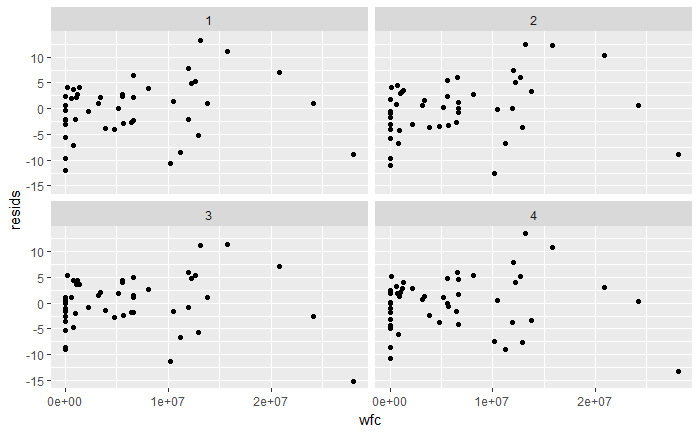

```r
# arrange the data to work nicely with ggplot
wfc_rep <- wfc_data[rep(seq_len(nrow(wfc_data)), length(eqs)), ]
wfc_rep$eq <- rep(seq_len(length(eqs)), each = nrow(wfc_data))
# add estimated residuals
resids <- t(laply(eqs, resid))
dim(resids) <- length(eqs)*nrow(wfc_data)
wfc_rep$resids <- resids
# plot
library(ggplot2)
ggplot(data = wfc_rep) +
  geom_point(aes(wfc, resids)) +
  facet_wrap(~ eq, nrow = 2)
```

Let’s take a closer look at the data points on the left of this graph …

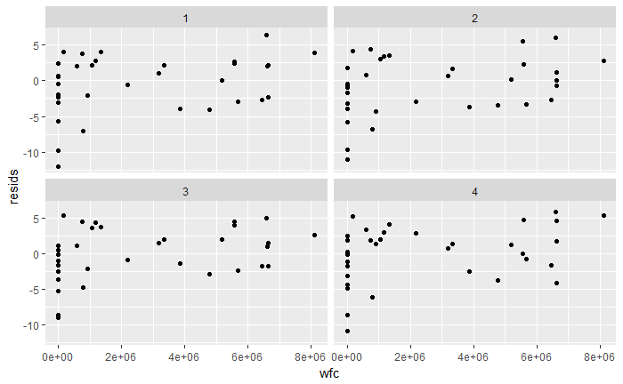

```r
library(dplyr)
ggplot(data = filter(wfc_rep, wfc < 1e7)) +
  geom_point(aes(wfc, resids)) +
  facet_wrap(~ eq, nrow = 2)
```

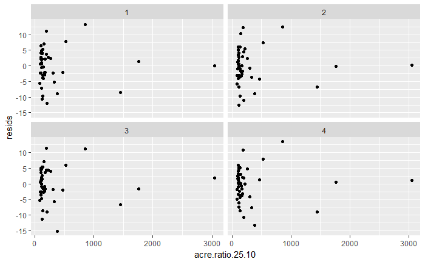

```r
ggplot(data = wfc_rep) +
  geom_point(aes(acre.ratio.25.10, resids)) +
  facet_wrap(~ eq, nrow = 2)
```

The same plot, with only the data close to the y axis:

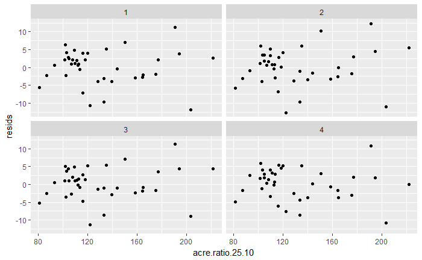

```r
ggplot(data = filter(wfc_rep, acre.ratio.25.10 < 250)) +
  geom_point(aes(acre.ratio.25.10, resids)) +
  facet_wrap(~ eq, nrow = 2)
```

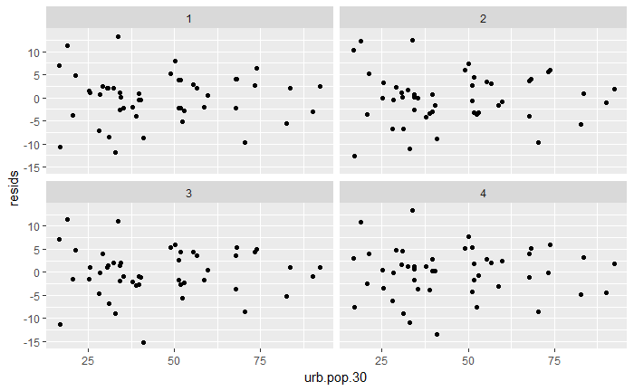

```r
ggplot(data = wfc_rep) +
  geom_point(aes(urb.pop.30, resids)) +
  facet_wrap(~ eq, nrow = 2)
```

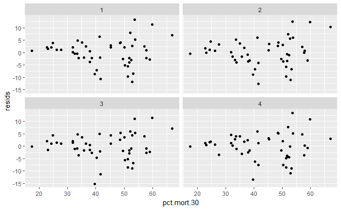

```r
ggplot(data = wfc_rep) +
  geom_point(aes(pct.mort.30, resids)) +
  facet_wrap(~ eq, nrow = 2)
```

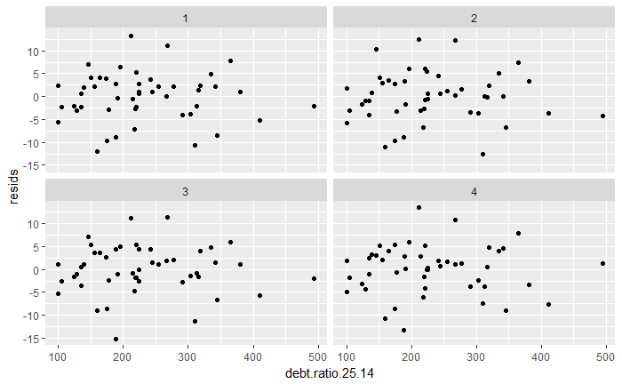

```r
ggplot(data = wfc_rep) +
  geom_point(aes(debt.ratio.25.14, resids)) +
  facet_wrap(~ eq, nrow = 2)
```

## Homoskedasticity

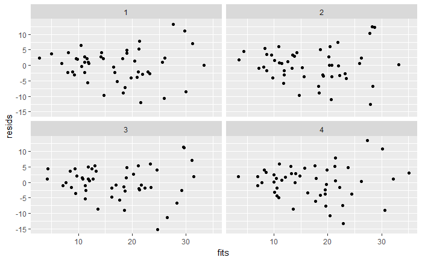

```r
fits <- t(laply(eqs, fitted))
dim(fits) <- length(eqs)*nrow(wfc_data)
wfc_rep$fits <- fits
ggplot(data = wfc_rep) +
  geom_point(aes(fits, resids)) +
  facet_wrap(~ eq, nrow = 2)
```

The preceding plots show fitted values vs estimated residuals. They suggest that the residuals may be heteroskedastic. The estimated residuals show increased spread as the fitted value increases.

## Normality

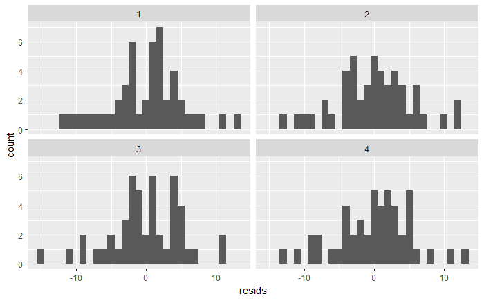

```r
ggplot(data = wfc_rep) +
  geom_histogram(aes(resids), binwidth = 1) +
  facet_wrap(~ eq, nrow = 2)
```